# Part I - Ford GoBike Dataset Exploration Analysis

## Preliminary Wrangling

```python
# import all packages and set plots to be embedded inline
import numpy as np
import pandas as pd
import matplotlib.pyplot as plt
import seaborn as sns
```

```python
# Loading the data
df = pd.read_csv('201902-fordgobike-tripdata.csv')
# Display the first few rows
df.head()
```

|  | duration_sec | start_time | end_time | start_station_id | start_station_name | start_station_latitude | start_station_longitude | end_station_id | end_station_name | end_station_latitude | end_station_longitude | bike_id | user_type | member_birth_year | member_gender | bike_share_for_all_trip |
| --- | --- | --- | --- | --- | --- | --- | --- | --- | --- | --- | --- | --- | --- | --- | --- | --- |
| 0 | 52185 | 2019-02-28 17:32:10.1450 | 2019-03-01 08:01:55.9750 | 21.0 | Montgomery St BART Station (Market St at 2nd St) | 37.789625 | -122.400811 | 13.0 | Commercial St at Montgomery St | 37.794231 | -122.402923 | 4902 | Customer | 1984.0 | Male | No |
| 1 | 42521 | 2019-02-28 18:53:21.7890 | 2019-03-01 06:42:03.0560 | 23.0 | The Embarcadero at Steuart St | 37.791464 | -122.391034 | 81.0 | Berry St at 4th St | 37.775880 | -122.393170 | 2535 | Customer | NaN | NaN | No |
| 2 | 61854 | 2019-02-28 12:13:13.2180 | 2019-03-01 05:24:08.1460 | 86.0 | Market St at Dolores St | 37.769305 | -122.426826 | 3.0 | Powell St BART Station (Market St at 4th St) | 37.786375 | -122.404904 | 5905 | Customer | 1972.0 | Male | No |
| 3 | 36490 | 2019-02-28 17:54:26.0100 | 2019-03-01 04:02:36.8420 | 375.0 | Grove St at Masonic Ave | 37.774836 | -122.446546 | 70.0 | Central Ave at Fell St | 37.773311 | -122.444293 | 6638 | Subscriber | 1989.0 | Other | No |
| 4 | 1585 | 2019-02-28 23:54:18.5490 | 2019-03-01 00:20:44.0740 | 7.0 | Frank H Ogawa Plaza | 37.804562 | -122.271738 | 222.0 | 10th Ave at E 15th St | 37.792714 | -122.248780 | 4898 | Subscriber | 1974.0 | Male | Yes |

```python
# Lets get the dataset describtion
df.describe()
```

|  | duration_sec | start_station_id | start_station_latitude | start_station_longitude | end_station_id | end_station_latitude | end_station_longitude | bike_id | member_birth_year |
| --- | --- | --- | --- | --- | --- | --- | --- | --- | --- |
| count | 183412.000000 | 183215.000000 | 183412.000000 | 183412.000000 | 183215.000000 | 183412.000000 | 183412.000000 | 183412.000000 | 175147.000000 |
| mean | 726.078435 | 138.590427 | 37.771223 | -122.352664 | 136.249123 | 37.771427 | -122.352250 | 4472.906375 | 1984.806437 |
| std | 1794.389780 | 111.778864 | 0.099581 | 0.117097 | 111.515131 | 0.099490 | 0.116673 | 1664.383394 | 10.116689 |
| min | 61.000000 | 3.000000 | 37.317298 | -122.453704 | 3.000000 | 37.317298 | -122.453704 | 11.000000 | 1878.000000 |
| 25% | 325.000000 | 47.000000 | 37.770083 | -122.412408 | 44.000000 | 37.770407 | -122.411726 | 3777.000000 | 1980.000000 |
| 50% | 514.000000 | 104.000000 | 37.780760 | -122.398285 | 100.000000 | 37.781010 | -122.398279 | 4958.000000 | 1987.000000 |
| 75% | 796.000000 | 239.000000 | 37.797280 | -122.286533 | 235.000000 | 37.797320 | -122.288045 | 5502.000000 | 1992.000000 |
| max | 85444.000000 | 398.000000 | 37.880222 | -121.874119 | 398.000000 | 37.880222 | -121.874119 | 6645.000000 | 2001.000000 |

```python
# Lets gets the number og null values in each instance
df.isnull().sum()
```

```
duration_sec                  0
start_time                    0
end_time                      0
start_station_id            197
start_station_name          197
start_station_latitude        0
start_station_longitude       0
end_station_id              197
end_station_name            197
end_station_latitude          0
end_station_longitude         0
bike_id                       0
user_type                     0
member_birth_year          8265
member_gender              8265
bike_share_for_all_trip       0
dtype: int64
```

```python
# Due to the size of dataset which is large comparing to the number of null values, I will remove them all
df.dropna(inplace= True) # inplace used here to perform the task immediatly
```

```python
# Now lets check again on the number of null values in dataset
print(f'The number of null values in the dataset is {df.isnull().sum().sum()}')
```

```
The number of null values in the dataset is 0
```

```python
# Its time now to check the duplicates rows
print(f'The number of DUPLICATED ROWS in the dataset is {df.duplicated().sum()}')
```

```
The number of DUPLICATED ROWS in the dataset is 0
```

```python
# Now lets check the data type for the start_time & end_time
df[['start_time', 'end_time']].info()
```

```
<class 'pandas.core.frame.DataFrame'>
Int64Index: 174952 entries, 0 to 183411
Data columns (total 2 columns):
 #   Column      Non-Null Count   Dtype
---  ------      --------------   -----
 0   start_time  174952 non-null  object
 1   end_time    174952 non-null  object
dtypes: object(2)
memory usage: 4.0+ MB
```

```python
# They seems string, lets covert them into datetime
df['start_time'] = pd.to_datetime(df['start_time'])
df['end_time'] = pd.to_datetime(df['end_time'])
```

```python
#  Now lets check again after change their data type
df[['start_time', 'end_time']].info()
```

```
<class 'pandas.core.frame.DataFrame'>
Int64Index: 174952 entries, 0 to 183411
Data columns (total 2 columns):
 #   Column      Non-Null Count   Dtype
---  ------      --------------   -----
 0   start_time  174952 non-null  datetime64[ns]
 1   end_time    174952 non-null  datetime64[ns]
dtypes: datetime64[ns](2)
memory usage: 4.0 MB
```

```python
# Now its time to split the time's columns into two column, one for date and the other for time, will be applied for both start_time & end_time
df['date_start'] = df['start_time'].dt.date  # Extract date
df['time_start'] = df['start_time'].dt.strftime('%H:%M:%S.%f')  # Extract time including milliseconds
# Now the same process for end_time column
df['date_end'] = df['end_time'].dt.date
df['time_end'] = df['end_time'].dt.strftime('%H:%M:%S.%f')
```

```python
# Now lets take a look at the dataset after perform the previous things
df.head(2)
```

|  | duration_sec | start_time | end_time | start_station_id | start_station_name | start_station_latitude | start_station_longitude | end_station_id | end_station_name | end_station_latitude | end_station_longitude | bike_id | user_type | member_birth_year | member_gender | bike_share_for_all_trip | date_start | time_start | date_end | time_end |
| --- | --- | --- | --- | --- | --- | --- | --- | --- | --- | --- | --- | --- | --- | --- | --- | --- | --- | --- | --- | --- |
| 0 | 52185 | 2019-02-28 17:32:10.145 | 2019-03-01 08:01:55.975 | 21.0 | Montgomery St BART Station (Market St at 2nd St) | 37.789625 | -122.400811 | 13.0 | Commercial St at Montgomery St | 37.794231 | -122.402923 | 4902 | Customer | 1984.0 | Male | No | 2019-02-28 | 17:32:10.145000 | 2019-03-01 | 08:01:55.975000 |
| 2 | 61854 | 2019-02-28 12:13:13.218 | 2019-03-01 05:24:08.146 | 86.0 | Market St at Dolores St | 37.769305 | -122.426826 | 3.0 | Powell St BART Station (Market St at 4th St) | 37.786375 | -122.404904 | 5905 | Customer | 1972.0 | Male | No | 2019-02-28 | 12:13:13.218000 | 2019-03-01 | 05:24:08.146000 |

```python
# As we see the new columns created, now its time to remove the old columns start_time, and end_time
df.drop(columns=['start_time'], inplace=True)
df.drop(columns=['end_time'], inplace=True)
# As I wrote above in the previous cells, the inplace argument used to perform the task immediately
```

```python
# Lets check again that the columns above removed
df.head(1)
```

|  | duration_sec | start_station_id | start_station_name | start_station_latitude | start_station_longitude | end_station_id | end_station_name | end_station_latitude | end_station_longitude | bike_id | user_type | member_birth_year | member_gender | bike_share_for_all_trip | date_start | time_start | date_end | time_end |
| --- | --- | --- | --- | --- | --- | --- | --- | --- | --- | --- | --- | --- | --- | --- | --- | --- | --- | --- |
| 0 | 52185 | 21.0 | Montgomery St BART Station (Market St at 2nd St) | 37.789625 | -122.400811 | 13.0 | Commercial St at Montgomery St | 37.794231 | -122.402923 | 4902 | Customer | 1984.0 | Male | No | 2019-02-28 | 17:32:10.145000 | 2019-03-01 | 08:01:55.975000 |

```python
# Now you have noticed that the columns  start_station_longitude & end_station_longitude values all nagative
# There is no reason to make them nagative so lets convert them into postive!
df['start_station_longitude'] = df['start_station_longitude'].abs() # using abs() method will convert all - values into +
df['end_station_longitude'] = df['end_station_longitude'].abs()
```

```python
# Now lets check these two columns
df[['start_station_longitude', 'end_station_longitude']].head(1)
```

|  | start_station_longitude | end_station_longitude |
| --- | --- | --- |
| 0 | 122.400811 | 122.402923 |

### What is the structure of your dataset?

> The dataset includes 183,412 trips with 16 features as follows:

### (Column) (Non-Null Count) (Datatype)

- duration_sec 183412 non-null int64
- start_time 183412 non-null object
- end_time 183412 non-null object
- start_station_id 183215 non-null float64
- start_station_name 183215 non-null object
- start_station_latitude 183412 non-null float64
- start_station_longitude 183412 non-null float64
- end_station_id 183215 non-null float64
- end_station_name 183215 non-null object
- end_station_latitude 183412 non-null float64
- end_station_longitude 183412 non-null float64
- bike_id 183412 non-null int64
- user_type 183412 non-null object
- member_birth_year 175147 non-null float64
- member_gender 175147 non-null object
- bike_share_for_all_trip 183412 non-null object

#### For Data Wrangleing Process:

- The null velue have been removed
- The start_time & end_time have been converted into datetime, they were 'object' as we see above
- The start_time & end_time have been splited into date_start, time_start, date_end, and time_end to make the structre better
- The start_time & end_time columns have been revomed after perform the split step
- The columns start_station_longitude and end_station_longitude values converted into + values, they were all - values! for no reason!!

### Now the dataset till here is fully cleaned

### What is the main feature of interest in your dataset?

> I'm interested in finding out the kind of user who spend the highest time in the trip (user_type) and (duration_sec)

### What features in the dataset do you think will help support your investigation into your feature of interest?

> Date of birth for the users will help me to differintiate between the users and their genders

## Univariate Exploration

### Question: Which is the peak that most of the customer use the bike in second? and what kind of the distrubition?

[figure not shown]

```python
# Now lets plot the histogram
plt.figure(figsize=(7, 3)) # Set the size of the plot
plt.hist(filtered_df['duration_sec'], bins=50)  # Adjust bins as needed
plt.xlabel('Trip Duration (seconds)') # Labeling the x axies
plt.ylabel('Frequency') # Labeling the y axies
plt.title('Distribution of Trip Durations') # Labeling the plot
plt.grid() # The grid gave me a clear view on the exact number or let say the distribution, as I said the grid (to me)
plt.show() # and its time to shoooow
```

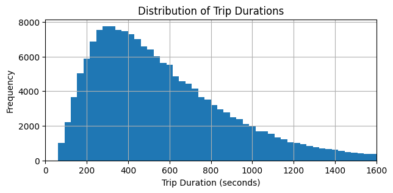

```python
# First lets filter out the outliers
threshold = 1600  # before that lets let threshold for filtering out outliers
filtered_df = df[df['duration_sec'] <= threshold]

# Now lets plot the histogram
plt.figure(figsize=(7, 3)) # Set the size of the plot
plt.hist(filtered_df['duration_sec'], bins=50)  # Adjust bins as needed
plt.xlim(0, 1600)  # Limit x-axis to focus on shorter durations
plt.xlabel('Trip Duration (seconds)') # Labeling the x axies
plt.ylabel('Frequency') # Labeling the y axies
plt.title('Distribution of Trip Durations') # Labeling the plot
plt.grid() # The grid gave me a clear view on the exact number or let say the distribution, as I said the grid (to me)
plt.show() # and its time to shoooow
```

#### As it clear that the histogram is RIGHT SKEWED distribution, the plots clarify that the most of the users their peak of using the bike *is between 300 to 350 seconds approximatly*

### Question: What is the top 10 stations that have trips?

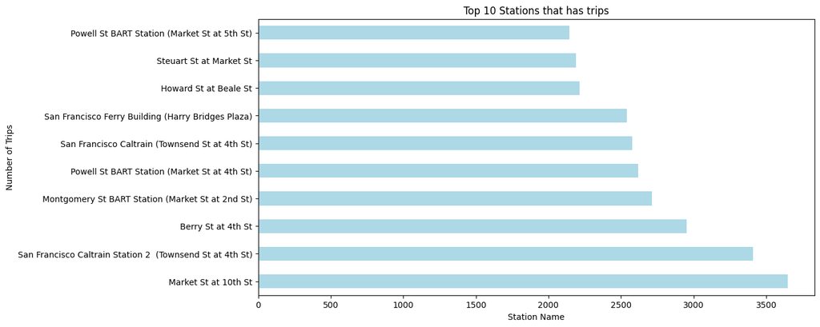

```python
# Now its time to draw the bar chat

# First lets count unique station names
unique_stations = df['start_station_name'].nunique()

# Lets get the number(count or frequency) of each station
station_counts = df['start_station_name'].value_counts()

# Now lets plot the most stations that use the bike from
plt.figure(figsize=(12, 6)) # as usual set the size of plot
station_counts.head(10).plot(kind='barh', color='lightblue') # here plotting the top 10 station
# the remains uaual steps
plt.xlabel('Station Name')
plt.ylabel('Number of Trips')
plt.title('Top 10 Stations that has trips')
plt.show()
```

#### The top 10 station that have trips is:

- Market St at 10th St
- San Francisco Caltrain Station 2 (Townsend St at 4th St)
- Berry St at 4th St
- Montgomery St BART Station (Market St at 2nd St)
- Powell St BART Station (Market St at 4th St)
- San Francisco Caltrain (Townsend St at 4th St)
- San Francisco Ferry Building (Harry Bridges Plaza)
- Howard St at Beale St
- Steuart St at Market St
- Powell St BART Station (Market St at 5th St)

### Discuss the distribution(s) of your variable(s) of interest. Were there any unusual points? Did you need to perform any transformations?

> For the first plot I needed to use grid to clarify the nubers for me and there is no need for legends or anything else due to the profiecncy of the plot in both, the distribution in both looks usual, next will be discuesd

### Of the features you investigated, were there any unusual distributions? Did you perform any operations on the data to tidy, adjust, or change the form of the data? If so, why did you do this?

> Yes, I perform for removing the outlier to make the data consistent to plot it well in the first plot(histogram) while the second I needed to take onlt the top (subset) of the dataset to clarify the desired point and it gives me exactly what I want to take without affecting on the consistency of the dataset

## Important note here:

### In the previous plots, I used the needed encodings, the unneeded have been eliminated like legend and etc..

## Bivariate Exploration

### Question: Based on the user age, Which is the generation that used the bike most?

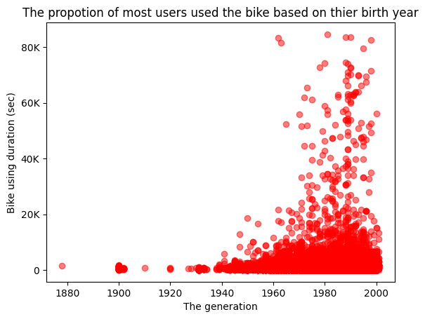

```python
# And now the first plot in bivariate plot is the scatter plot, I will create the relationship between
# member_birth_year and duration_sec, we will see the propotion of who used the bike most based on thier birth year
plt.scatter(df['member_birth_year'], df['duration_sec'], color='red', alpha=0.5)
# I used alpha as 0.5 to make the propotion well focues on the places that contains many users
# the usual below
plt.title('The propotion of most users used the bike based on thier birth year')
plt.xlabel('The generation')
plt.ylabel('Bike using duration (sec)');

# Now here, in y-axis the numbers looks not well for example: 20000, and 40000
# and while they all more than 20K, it better to make them ends with K like this 20K insted of 20000
# I did some search for the best way to apply it, and it turns out that their is a library needs to be import
# Which is ticker from matplotlib, and we need to make function that convert the regular numbers and make it ends with K
# As I did below
import matplotlib.ticker as mtick # Import this library
def thousands_formatter(x, pos): # Here the function that need to make to convert as I searched
    if x == 0:
        return '0' # Here keep the 0 as is without adding K
    else:
        return f'{int(x / 1000)}K' # And here if the number from the thousands will be converted
# And now its time to use the library that imported to apply the function above
plt.gca().yaxis.set_major_formatter(mtick.FuncFormatter(thousands_formatter))
```

### Still the plot is not well so we need to make it more profional!

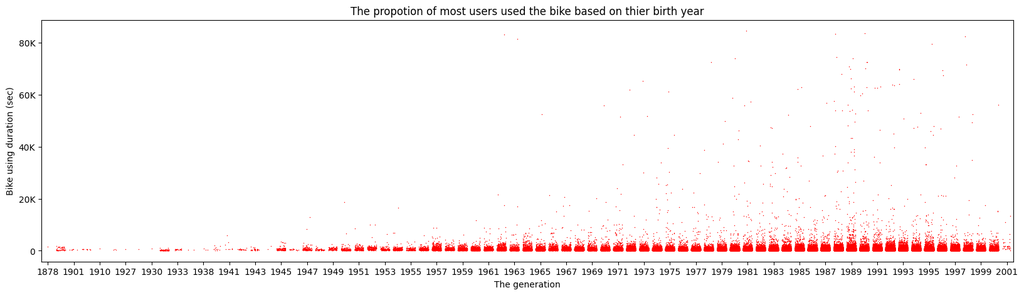

```python
# Change birth year to int, to do it NaN balues have to be droped
# Name the new dataset data
data = df.dropna(subset= 'member_birth_year').copy()
# Change to int
data['member_birth_year'] = data['member_birth_year'].astype(int)

# Set plot dimenstions
plt.figure(figsize=(20,5))

 # And now the first plot in bivariate plot is the scatter plot, I will create the relationship between
# member_birth_year and duration_sec, we will see the propotion of who used the bike most based on thier birth year
sns.stripplot(data=data, x= 'member_birth_year', y='duration_sec', color='red', size=1, jitter=0.35)
# I used alpha as 0.5 to make the propotion well focues on the places that contains many users
# the usual below
plt.title('The propotion of most users used the bike based on thier birth year')
plt.xlabel('The generation')
plt.ylabel('Bike using duration (sec)');

# Get current tick postions and labels
pos, lab=plt.xticks()
# Set new tick labels
plt.xticks(pos[::2], lab[::2]);

# Now here, in y-axis the numbers looks not well for example: 20000, and 40000
# and while they all more than 20K, it better to make them ends with K like this 20K insted of 20000
# I did some search for the best way to apply it, and it turns out that their is a library needs to be import
# Which is ticker from matplotlib, and we need to make function that convert the regular numbers and make it ends with K
# As I did below
import matplotlib.ticker as mtick # Import this library
def thousands_formatter(x, pos): # Here the function that need to make to convert as I searched
    if x == 0:
        return '0' # Here keep the 0 as is without adding K
    else:
        return f'{int(x / 1000)}K' # And here if the number from the thousands will be converted
# And now its time to use the library that imported to apply the function above
plt.gca().yaxis.set_major_formatter(mtick.FuncFormatter(thousands_formatter))
```

#### The most generation that got used the bike is 1950s to 2000s based on the figure

### Question: Which the users whose used the bike long time? Particapiate or not?

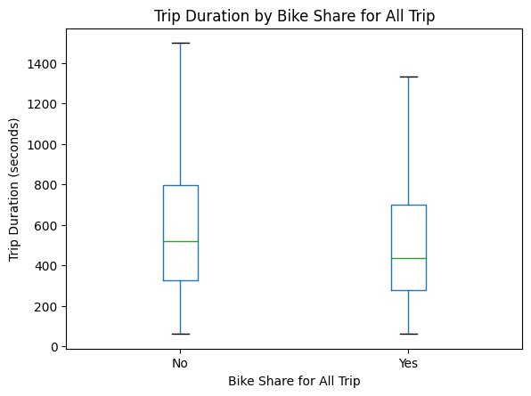

```python
# Now its time to plot the box plot
# Will be repreasent as The trip duration by the users who shared thier trips
df.boxplot(column='duration_sec', by='bike_share_for_all_trip', grid=False, showfliers=False) # showfliers as false to see the box plot well
plt.title('Trip Duration by Bike Share for All Trip')
plt.suptitle('')  # To show the above title, it will not be well if this not included after search
plt.xlabel('Bike Share for All Trip')
plt.ylabel('Trip Duration (seconds)')
plt.show()
```

#### Here I explored the difference in trip durations between users who participated in a bike-share for all trips versus those who didn't.

### Question: Usually, Which is the highest path for (start to take and submit) the bike?

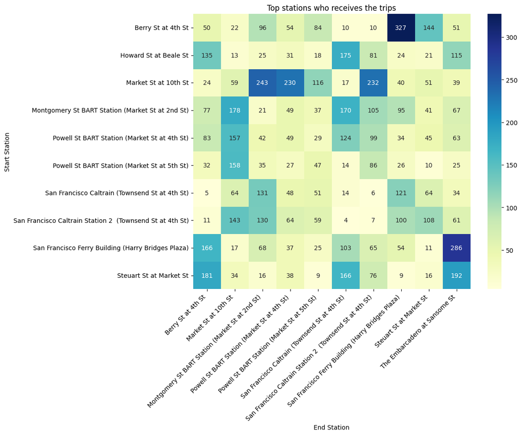

```python
# I will create heat map due to the available data that helps in making it
# Lets divide the work into steps to take a good understanding!
# For FYI I took the 1,2 & 3 from searching due to the size of the data which is too large

# Step 1: Count trips for each station
top_n = 10  # Set the number of top stations to keep
top_start_stations = df['start_station_name'].value_counts().nlargest(top_n).index
top_end_stations = df['end_station_name'].value_counts().nlargest(top_n).index

# Step 2: Filter the df to only include top stations
filtered_df = df[df['start_station_name'].isin(top_start_stations) &
                  df['end_station_name'].isin(top_end_stations)]

# Step 3: Prepare the data - create a pivot table
heatmap_data = filtered_df.pivot_table(index='start_station_name',
                                        columns='end_station_name',
                                        values='duration_sec',  # You can use duration_sec
                                        aggfunc='count',  # Count the number of trips
                                        fill_value=0)  # Fill missing values with 0 if there any

# Step 4: Now let come to the desired point, creating the heat map!
plt.figure(figsize=(10, 8)) # Lets set the size to the best possible for looking the plot
sns.heatmap(heatmap_data, cmap='YlGnBu', annot=True, fmt='g')  # Set annot to true to see counts, cmap to YlGnBu to make the color good for looking
plt.title('Top stations who receives the trips')
plt.xlabel('End Station')
plt.ylabel('Start Station')
plt.xticks(rotation=45, ha='right')  # Rotate x-axis labels for better readability
plt.show()
# It will show one important encoding whcui is the colorbar! it will help to differantiate bwteen heats
```

#### As we see it turns out the hiest people used the following path to start and finish their trip! starting from Berry St at 4th St, and submit their bike in San Francisco Ferry Building (Harry Bridges Plaza)

### Talk about some of the relationships you observed in this part of the investigation. How did the feature of interest vary with other features in the dataset?

> In this part the duration in seconds helps a lot to make the relationship among the dufferents plot such as the scatter and box plots, I can say that its the main one while the others helps to make the relationships

### Did you observe any interesting relationships between the other features?

> Yes, Specifically in the heat map, the relationships between the start & end station gave me an idea about the most path that really works and active!!

## Multivariate Exploration

### Question: From the facets scatters plot, Who is the highest propotion in the latitude?

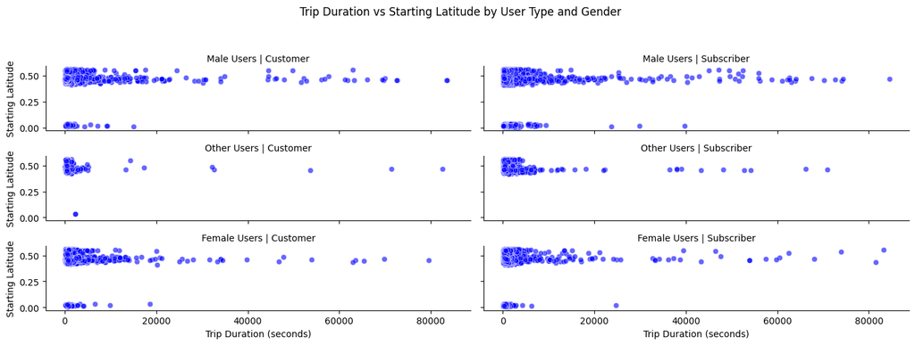

```python
# The facet plots will be created and it will show Trip Duration vs Starting Latitude by User Type and Gender

# First for better encodings the starting latitude will be normalized to use it starting from 0 with relative frequency
# Normalize starting latitude
df['normalized_start_latitude'] = df['start_station_latitude'] - df['start_station_latitude'].min()

# Lets create a Facet Plot for trip duration vs starting latitude by user type and gender
plt.figure(figsize=(14, 10)); # The size as usual
facet = sns.FacetGrid(df, col='user_type', row='member_gender', height=4, aspect=1.5) # Here creating the plot, the height and aspect about the layout in the front
facet.map(sns.scatterplot, 'duration_sec', 'normalized_start_latitude', alpha=0.6, color='blue') # The facets will be scatters based on the data that I have
facet.set_axis_labels('Trip Duration (seconds)', 'Starting Latitude') # Here to set the label for the x and y axises
facet.set_titles(col_template='{col_name}', row_template='{row_name} Users') # Here to set the label for the column and rwos of the facets
plt.suptitle('Trip Duration vs Starting Latitude by User Type and Gender', y=1.05)
facet.fig.set_size_inches(14,5)
plt.tight_layout()
plt.show(); # In each row there are 2 columns and in each column there are 3 rows, for me this is better!

# From above I googled them to get the optimal ways to draw the facets
```

#### The male users who subscribe in the program seems to be the highest proption of the latitude

> Note: The size of this plot appropiate to me, that is why settd to this size

### Question: How do user types (Customers vs Subscribers) differ in their trip duration, starting latitude, and starting longitude based on the pair plot?

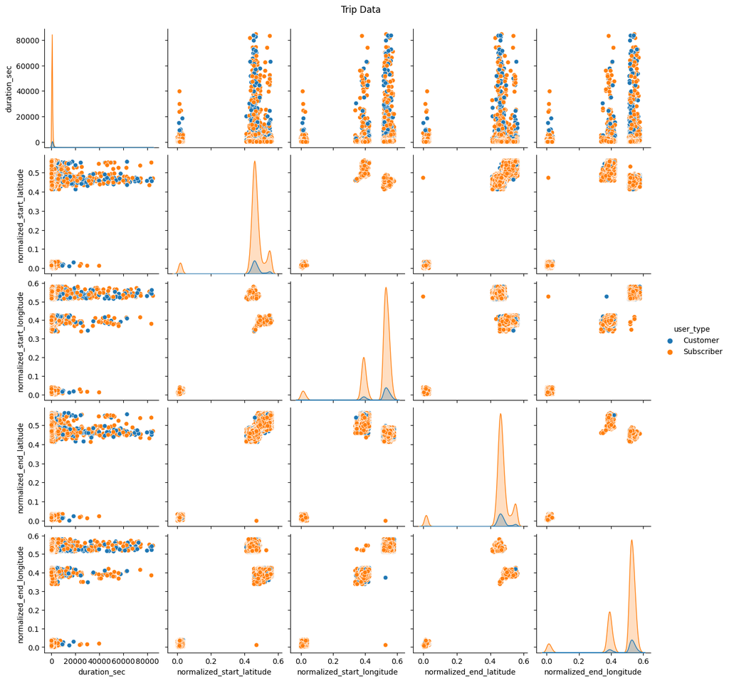

```python
# And now we reach to the final plot which matrix plot that will repreasent each one of the numaric cols with the user type!
# Its very interested to see the
# Selecting numerical columns for the plot matrix(pair plot)
# Normalize longitude and latitude to start from 0 and then will be relative frequency for better organizing
df['normalized_start_latitude'] = df['start_station_latitude'] - df['start_station_latitude'].min()
df['normalized_start_longitude'] = df['start_station_longitude'] - df['start_station_longitude'].min()
df['normalized_end_latitude'] = df['end_station_latitude'] - df['end_station_latitude'].min()
df['normalized_end_longitude'] = df['end_station_longitude'] - df['end_station_longitude'].min()

# Select relevant columns for the pairplot with normalized values as you see
numerical_cols_normalized = [
    'duration_sec',
    'normalized_start_latitude',
    'normalized_start_longitude',
    'normalized_end_latitude',
    'normalized_end_longitude'
]

# The above process I need a little search to get them well as I want

# Now its time to the BIG SHOW, create a pairplot with hue set to user_type (the legend will appear in the right)
# When they match two col like duration_sec vs duration_sec will repreasented as line chart, otherwise it will be scatter
sns.pairplot(df[numerical_cols_normalized + ['user_type']], hue='user_type')
plt.suptitle('Trip Data', y=1.02)
plt.show()
```

### Talk about some of the relationships you observed in this part of the investigation. Were there features that strengthened each other in terms of looking at your feature(s) of interest?

> Overall the longitude and landtitude helps me directly in this part to investigate and find the well results!

### Were there any interesting or surprising interactions between features?

> As we see in the above pair plot, the interesting thing that pulled me is the gaps between the latitude as well as the longtitude

## Conclusions

### In this Ford GoBike Dataset Exploration Analysis

- This dataset downloaded from Udacity and licensed by Ford GoBike.
- It includes 183,412 trips with 16 features

##### For Data Wrangleing Process:

- The null velue have been removed
- The start_time & end_time have been converted into datetime, they were 'object' as we see above
- The start_time & end_time have been splited into date_start, time_start, date_end, and time_end to make the structre better
- The start_time & end_time columns have been revomed after perform the split step
- The columns start_station_longitude and end_station_longitude values converted into + values

#### For Univariate analysis:

- I did the histogram, and bar chart
- for the histogram I asked, Which is the peak that most of the customer use the bike in second? and what kind of the distrubition? and to answer that I had to create the plot and it turns out that, as it clear that the histogram is RIGHT SKEWED distribution, the plots clarify that the most of the users their peak of using the bike is between 300 to 350 seconds approximatly
- for th bar chart I asked about the top 10 stations that have trips? and two of them were Market St at 10th St, and San Francisco Caltrain Station 2 (Townsend St at 4th St)

#### For Bivariate analysis:

- I did the scatter, box plots, and the heat map
- for the scatter, I asked based on the user age, Which is the generation that used the bike most? they were bewteen 1950s and 2000s
- for the box, Which the users whose used the bike long time? Particapiate or not? they are who NOT participate
- for the heat map, Usually, Which is the highest path for (start to take and submit) the bike? and they starting from Berry St at 4th St, and submit their bike in San Francisco Ferry Building (Harry Bridges Plaza)

#### Finally, This exploration analysis was fantastic and enjoyable!